# 2D-s ábrák

## Kétváltozós függvények ábrázolásai, kontúrábrák, hőtérképek

Kétváltozós függvények megjelenítése az egy változósokéhoz hasonlóan, adatgyűjtéssel vagy mintavételezéssel kezdődik. A már ismert `linspace()` függvényt kombinálva a `meshgrid()` függvénnyel a múlt órán megismert módon mintavételezünk egy kétváltozós paraméterteret:

```python
x2,y2 = meshgrid(linspace(-4,4,50),linspace(-3,3,50)) #mintavételezési pontok legyártása
z2 = sin(x2) ** 10 + cos(10 + y2 * x2) * cos(x2)          #függvény kiértékelés
```

A fenti kódsor tehát legyártott három tömböt. Az első kettő tartalmazza a (2 indexes array formájában) a mintavételezési pontok $x$ és $y$ koordinátáját. A `z2` változó pedig a kiértékelt függvényt. Most már csak ábrázolni kell! Ezt legegyszerűbben - ahogy már láttuk - a `pcolor()` függvény teszi meg:

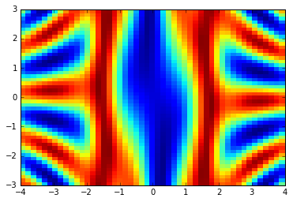

```python
pcolor(x2,y2,z2)
```

Hogy egy adott szín mit jelent, azt a `colorbar()` függvény segítségével tudhatjuk meg.

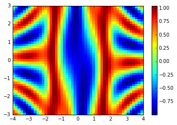

```python
pcolor(x2,y2,z2)
colorbar()
```

Sok színsála létezik. Mindegyiknek megvan a maga előnye és hátránya. A [matplotlib színskálák](http://matplotlib.org/examples/color/colormaps_reference.html) oldalán néhány megnevezett színsála közzül a `cmap` kulcsszó segítségével tudunk válogatni.

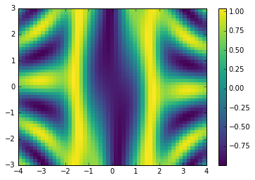

```python
pcolor(x2,y2,z2,cmap='viridis')
colorbar()
```

Kétváltozós függvényeket szokás kontúrok segítségével is ábrázolni. Egy kontúrvonal azokat a pontokat tartalmazza, ahol az adott két változós függvény ugyanazt az értéket veszi fel. A `contour()` függvény segítségével tudunk kontúrábrákat generálni:

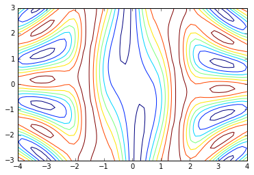

```python
contour(x2,y2,z2)
```

Ha csak megadott kontúrértékekre vagyunk kíváncsiak, akkor azt a `levels` kulcsszó használatával tehetjük meg.

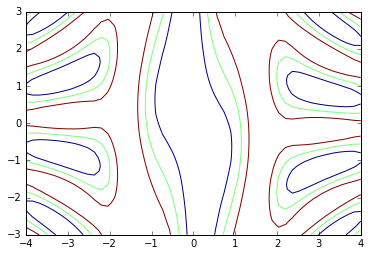

```python
contour(x2,y2,z2,levels=[-0.5,0,0.5])
```

A `clabel()` függvény segítségével a kontúr vonalakat a megfelelő értékek szerint tudjuk feliratozni.

```
<a list of 28 text.Text objects>
```

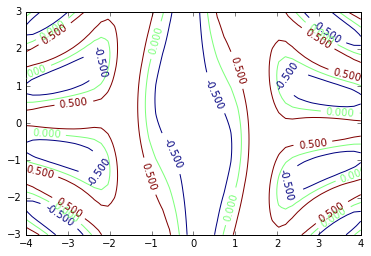

```python
cs=contour(x2,y2,z2,levels=[-0.5,0,0.5])
clabel(cs)
```

A `contourf()` függvény a `pcolor()` és a `contour()` függvények jó tulajdonságait ötvözi. Segítségével kitöltött szines ábrákat tudunk generálni, amelyek jobban illeszkednek a megjelenítendő függvény alakjához.

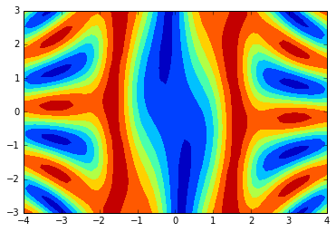

```python
contourf(x2,y2,z2)
```

A `levels` kulcsszó segítségével feljebb vehetjük a felbontást.

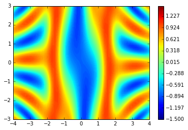

```python
contourf(x2,y2,z2,levels=linspace(-1.5,1.5,100))
colorbar()
```

Előfordulhat, hogy a mintavételezés valamilyen oknál fogva nem volt egyenletes. Ekkor az adatpontok [háromszögelésének](https://hu.wikipedia.org/wiki/Delauney-h%C3%A1romsz%C3%B6gel%C3%A9s) segítségével lehet ábrázolni a kérdéses függvényt. Az alábbiakban erre látunk példát.

Gyártsunk le először is véletlenszerűen síkbeli pontokat!

```python
tx,ty = [8*rand(50*50)-4,6*rand(50*50)-3]                 #mintavételezési pontok legyártása
```

Értékeljük ki ezekben a véletlen mintavételezési pontokban az ábrázolni kívánt függvényt!

```python
tz = sin(tx) ** 10 + cos(10 + ty * tx) * cos(tx)          #függvény kiértékelés
```

Ha az adatpontok rendezetlenek, akkor a `tripcolor()`, `tricontour()` és `tricontourf()` függvényeket használhatjuk a `pcolor()`, `contour()`, illetve a `contourf()` függvényekkel teljesen analóg módon!

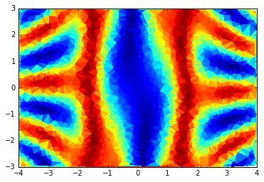

```python
tripcolor(tx,ty,tz)
```

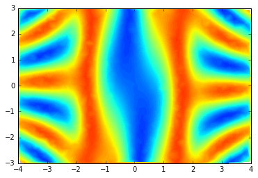

```python
tricontourf(tx,ty,tz,linspace(-1.5,1.5,100))
```

## Vektorterek ábrázolási lehetőségei, nyílseregek és áramvonalak

A fizikában gyakran van dolgunk erőterekkel. Gondoljunk csak az elektrodinamikára vagy a meteorológiára. Vizsgáljuk meg az eddig ábrázolt kétváltozós függvény gradiensét. A síkbeli gradiensvektor az alábbiak szerint adódik:

```python
u=-y2*sin(x2*y2 + 10)*cos(x2) + 10*sin(x2)**9*cos(x2) - sin(x2)*cos(x2*y2 + 10)
v=-x2*sin(x2*y2 + 10)*cos(x2)
```

A `quiver()` függvény segítségével a sík minden pontjához, amelyet az `x2` és `y2` tömbök definiálnak, egy az `u` és `v` tömbök által definiált vektort tudunk rendelni. Azaz a tér `(x2[i],y2[i])` pontjába egy `(u[i],v[i])` vektor kerül!

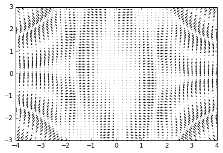

```python
quiver(x2,y2,u,v)
```

Rajzoljuk csak minden harmadik vektort ki, piros színnel és kicsit vastagabban.

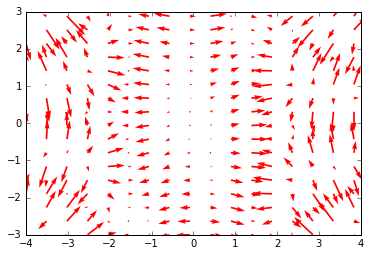

```python
quiver(x2[::3, ::3], y2[::3, ::3], u[::3, ::3], v[::3, ::3],
    color='red',width=0.005)
```

Mint ahogy azt fent is említettük, további részletekért érdemes a dokumentációt böngészni!

```python
?quiver
```

A `quiver()` alternatívája az áramvonal-ábrázolás, avagy a `streamplot()`:

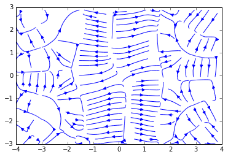

```python
streamplot(x2[::3, ::3], y2[::3, ::3], u[::3, ::3], v[::3, ::3])
```

További részletek a dokumentációban:

```python
?streamplot
```

A `streamplot()`-ot és a `quiver()`-t használhatjuk közösen a `pcolor()` és a kontúrkészítő rutinokkal!

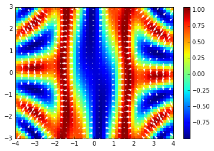

```python
pcolor(x2,y2,z2)
colorbar()
quiver(x2[::2,::2],y2[::2,::2],u[::2,::2],v[::2,::2],color='white',width=0.005)
```

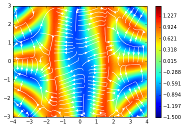

```python
contourf(x2,y2,z2,levels=linspace(-1.5,1.5,100))
colorbar()
streamplot(x2[::3, ::3], y2[::3, ::3], u[::3, ::3], v[::3, ::3],color='white')
```

## Ábrafeliratozás, nyilazás, ábratömbök

Egy ábra véglegesítése során sokszor előfordulhat, hogy valamilyen magyarázó szövegre van szükség, esetleg az ábra egy részét valamiért ki szeretnénk emelni. Ezt a `text()` és az `annotate()` függvények segítségével tehetjük meg. A `text()` függvény 3 alapvető bemenő paraméterrel rendelkezik. Az első kettő egy koordináta, a harmadik pedig egy string. Nézzünk egy példát!

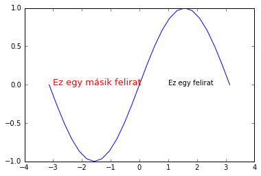

```python
plot(x,y);
text(1,0,'Ez egy felirat')
text(-3,0,'Ez egy másik felirat',fontsize=13,color='red')
```

Ha egy részt ki szeretnénk emelni, akkor arra a legalkalmasabb megoldás az `annotate()`. Ezen függvény segítségével egy "rámutató" nyilat és egy magyarázó szöveget helyezhetünk el az ábrán. Az első bemenő paraméter egy string, ami a magyarázat, ezen kívül kulcsszavakkal vezéreljük a függvény további viselkedését. Az `xy` kulcsszó a kiemelni kívánt pont helye. Az `xytext` a magyarázat helye, az `arrowprops` pedig egy olyan `dict`-et tartalmaz, amely a nyíl tulajdonságait határozza meg.

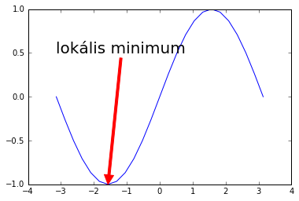

```python
plot(x,y)
annotate('lokális minimum', xy=(-pi/2, -1), xytext=(-pi, 0.5),arrowprops=dict(color='red',width=3),fontsize=20)
```

```python
?annotate
```

Végül lássunk néhány példát ábratömbökre! A `subplot()` függvény segítségével tudunk ábratömböt vagy ábrarácsot generálni. Ha egy kódcellába több `subplot()` parancsot írunk, akkor minden `subplot()` parancs alatti ábrázolórutin külön alábrára kerül. A `subplot(n,m,i)` kód jelentése a következő: ami ezután jön, azt rajzold egy n*m-es ábratömb i-edik alábrájába. Vigyázzunk rá, hogy itt i nem haladhatja meg n*m-et!

Lássunk néhány példát:

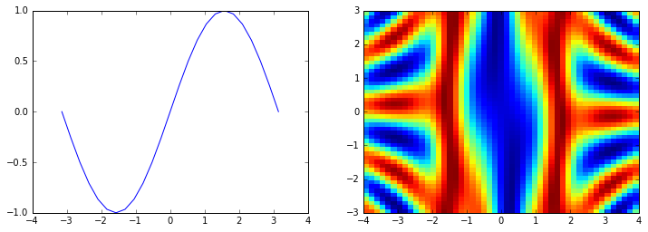

```python
figsize(12,4) #ábraméret nagyítása vízszintesen
subplot(1,2,1)
plot(x,y)
subplot(1,2,2)
pcolor(x2,y2,z2)
```

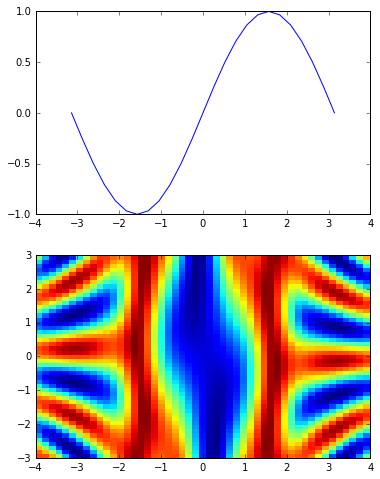

```python
figsize(6,8) #ábraméret nagyítása függőlegesen
subplot(2,1,1)
plot(x,y)
subplot(2,1,2)
pcolor(x2,y2,z2)
```

# Ábra mentése

A legenerált ábrákat a `savefig()` paranccsal tudjuk kimenteni képfile-okba.

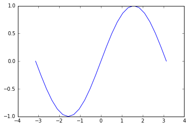

```python
figsize(6,4) # megszokott ábraméret visszaállítása
plot(x,y)
savefig('az_en_abram.png')
```